# Introduction to Open Data Science - Course Project

## If you’re peer reviewing this after 13 Dec…

..you might be wondering why it looks this crappy. I had major issues with knitr and had to revert to knit2html, which apparently uses an old version of Rmarkdown, and I ran horribly out of time while troubleshooting. Sorry!

# Chapter 1

[Now playing](https://www.youtube.com/watch?v=bhlD1XfiEJE)  
[My GitHub IODS repository](https://github.com/voikukas/IODS-project)\

## **How am I feeling right now?** 5 minutes after switching from my UH computer to my personal computer, I finally got the environment working (after struggling with my work computer for 6 hours)! Feeling slightly annoyed now.

**Impressions from R for health data science & Exercise set 1**  
I’m already slightly familiar with programming and R, so I didn’t go through everything in great detail.  
Many of the practical examples and recommendations, such as the one about equivalence & rounding, seem very useful and probably will have saved me from a big headache. On the other hand, I skimmed through the import data section as it had nothing new for me. Everything else will serve as a great reminder.

```r
# This is a so-called "R chunk" where you can write R code.

date()
```

```
## [1] "Tue Dec 13 02:32:39 2022"
```

# Regression and model validation

*Describe the work you have done this week and summarize your learning.*

This week, I worked with the exercise set and read through R for Health Data Science to be able to answer the stats questions. I learned something new about plotting (ggpairs is super nifty) and statistical analysis with R. I don’t want to touch SPSS ever again.

```r
date()
```

```
## [1] "Tue Dec 13 02:32:39 2022"
```

```r
library(ggplot2)
library(GGally)
library(dplyr)
learning2014 <- read.csv("data/learning2014.csv")
```

## 1.

The data contain a condensed version of a full questionnaire dataset (details at https://www.mv.helsinki.fi/home/kvehkala/JYTmooc/JYTOPKYS2-meta.txt). Students in an introductory statistics course have answered a questionnaire regarding their approaches and attitudes towards learning and statistics; additionally, their exam points and other background variables have been collected.

Questionnaire variables: Respondents have given their answers on a 1-5 scale. From the raw data, certain variables have been combined (and scaled back) in order to measure the respondents’ use of the following learning approaches: deep (variable name deep), strategic (stra), and surface (surf). The variable ‘attitude’ combines questions about respondents’ attitude towards statistics.

Other variables: gender age points (note: respondents with 0 points have been removed)

```r
dim(learning2014)
```

```
## [1] 166   7
```

```r
head(learning2014)
```

```
##   gender age attitude     deep  stra     surf points
## 1      F  53      3.7 3.583333 3.375 2.583333     25
## 2      M  55      3.1 2.916667 2.750 3.166667     12
## 3      F  49      2.5 3.500000 3.625 2.250000     24
## 4      M  53      3.5 3.500000 3.125 2.250000     10
## 5      M  49      3.7 3.666667 3.625 2.833333     22
## 6      F  38      3.8 4.750000 3.625 2.416667     21
```

There are 166 respondents (rows) and 7 variables (columns).

## 2.

```r
# Checking number of female respondents
nrow(filter(learning2014, gender =="F"))
```

```
## [1] 110
```

[output not shown]

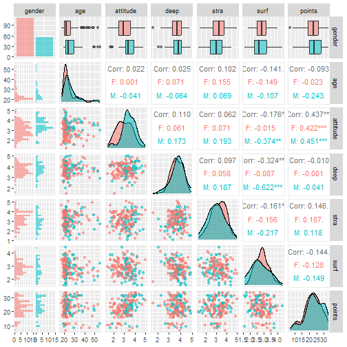

```r
# Graphical overview & variable summaries
p <- ggpairs(learning2014, mapping = aes(col=gender, alpha=.3), lower = list(combo = wrap("facethist", bins = 20)))

p
```

There are 110 female respondents and 56 male respondents, which may bias the data towards female respondents. Thus, it makes sense to explore the data grouped by gender.  
By looking at the data densities grouped by gender, we can see that the distributions are somewhat similar in all variables. Largest gender differences seem to show in attitude (male respondents report a more neutral/positive attitude).

Most respondents are under 30 years old, but ages range from 17 to 55. There are no significant interactions between age and other variables.

The strongest correlation can be found between attitude and points (.437, p < .001). In males, there is a negative correlation between attitude and surface approach (r = -.374, p < .01). Males also show a strong negative correlation between deep and surface approaches (-.622, p < .001).

While there is a negative correlation between strategic and surface approaches (-.16, p < .05), it is not present in any of the genders separately.

## 3. & 4.

Chosen explanatory variables: attitude, deep, and surface approach

```r
model <- lm(points ~ attitude + deep + surf, data = learning2014)
summary(model)
```

```
##
## Call:
## lm(formula = points ~ attitude + deep + surf, data = learning2014)
##
## Residuals:
##      Min       1Q   Median       3Q      Max
## -16.9168  -3.1487   0.3667   3.8326  11.3519
##
## Coefficients:
##             Estimate Std. Error t value Pr(>|t|)
## (Intercept)  18.3551     4.7124   3.895 0.000143 ***
## attitude      3.4661     0.5766   6.011 1.18e-08 ***
## deep         -0.9485     0.7903  -1.200 0.231815
## surf         -1.0911     0.8360  -1.305 0.193669
## ---
## Signif. codes:  0 '***' 0.001 '**' 0.01 '*' 0.05 '.' 0.1 ' ' 1
##
## Residual standard error: 5.313 on 162 degrees of freedom
## Multiple R-squared:  0.2024,	Adjusted R-squared:  0.1876
## F-statistic:  13.7 on 3 and 162 DF,  p-value: 5.217e-08
```

Variables deep and surf do not have a statistically significant relationship with points; adjusting the model.

```r
model <- lm(points ~ attitude + stra, data = learning2014)
summary(model)
```

```
##
## Call:
## lm(formula = points ~ attitude + stra, data = learning2014)
##
## Residuals:
##      Min       1Q   Median       3Q      Max
## -17.6436  -3.3113   0.5575   3.7928  10.9295
##
## Coefficients:
##             Estimate Std. Error t value Pr(>|t|)
## (Intercept)   8.9729     2.3959   3.745  0.00025 ***
## attitude      3.4658     0.5652   6.132 6.31e-09 ***
## stra          0.9137     0.5345   1.709  0.08927 .
## ---
## Signif. codes:  0 '***' 0.001 '**' 0.01 '*' 0.05 '.' 0.1 ' ' 1
##
## Residual standard error: 5.289 on 163 degrees of freedom
## Multiple R-squared:  0.2048,	Adjusted R-squared:  0.1951
## F-statistic: 20.99 on 2 and 163 DF,  p-value: 7.734e-09
```

We’re looking at the relationship between two variables; we’d like to see how “attitude” explains the obtained course points. Using ordinary least squares, simple linear regression fits a line to the observed data (where y is the dependent variable and x is the explanatory variable). Residuals are the differences between observed values and the fitted line(s). The median of residuals is .56, which suggests that the data fits the model quite nicely (but further analyses show whether this is true or not).

The coefficient intercept estimates: when attitude+stra = 0, points are at ~9 (p < .001 at null hypothesis, so when slope is at 0). The coefficient estimate of the explanatory variables are the slopes of the regression line (p < .001 for attitude, p < .1 for stra).

The adjusted R-squared stands for the coefficient of determination and is an indicator of how much of the variability is explained by the explanatory variable. It is at .1951, which is not that great. Thus, attitude and stra are not the only factors explaining the scores.

## 5.

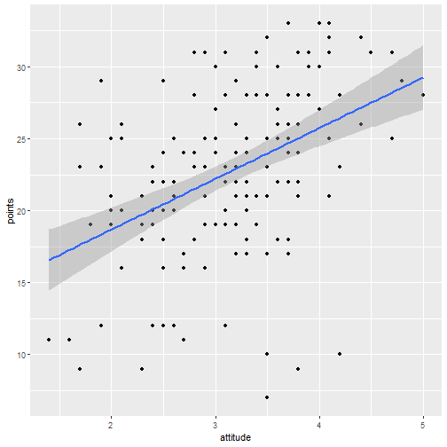

```r
# Scatter plots
qplot(attitude, points, data = learning2014) + geom_smooth(method = "lm")
```

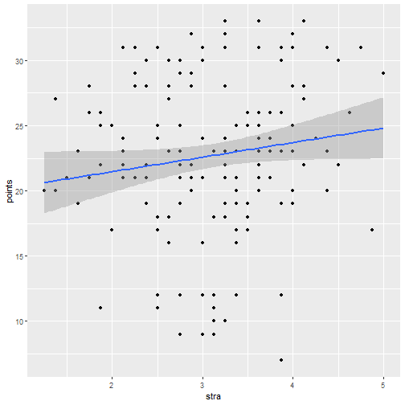

```r
qplot(stra, points, data = learning2014) + geom_smooth(method = "lm")
```

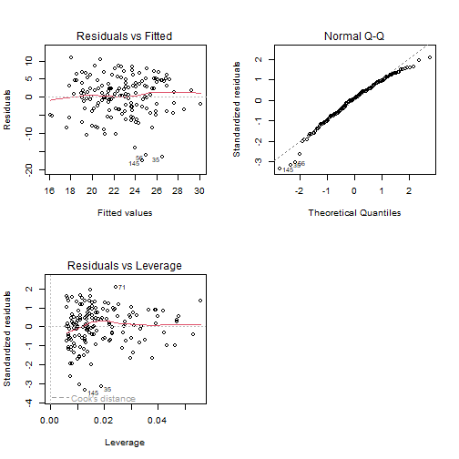

```r
# Diagnostic plots
par(mfrow=c(2,2))
plot(model, which=c(1,2,5))
```

A simple regression model assumes

*A linear relationship between predictors and outcome* The scatter plots describe a somewhat linear pattern.

*Independence of residuals* The observations are independent (each data point represents an individual).

*Normal distribution of residuals* Q-Q plot looks normally distributed.

*Equal variance of residuals* Residuals vs fitted plot looks balanced.

# Logistic regression

```r
date()
```

```
## [1] "Tue Dec 13 02:32:45 2022"
```

```r
library(ggplot2)
library(GGally)
library(dplyr)
alc <- read.csv("data/alc.csv")
```

## 2.

The data, gathered of students in secondary education in two Portuguese schools, describe student achievement in Portuguese and mathematics. Detailed description of the data set and all attributes can be found [here](https://archive.ics.uci.edu/ml/datasets/Student+Performance).

Our version is modified from the original as follows: Only students with both Portuguese and maths grades available have been included.

Averaged grades: G1 first period grade average of Math and Portuguese (0-20) G2 second period grade average of Math and Portuguese (0-20) G3 third period grade average of Math and Portuguese (0-20)

Variables on alcohol use: alc_use average alcohol use based on workday and weekend alcohol consumption (from 1 - very low to 5 - very high) high_use high use of alcohol: TRUE if alc_use is > 2; otherwise FALSE

```r
head(alc)
```

```
##   school sex age address famsize Pstatus Medu Fedu     Mjob     Fjob     reason guardian
## 1     GP   F  18       U     GT3       A    4    4  at_home  teacher     course   mother
## 2     GP   F  17       U     GT3       T    1    1  at_home    other     course   father
## 3     GP   F  15       U     LE3       T    1    1  at_home    other      other   mother
## 4     GP   F  15       U     GT3       T    4    2   health services       home   mother
## 5     GP   F  16       U     GT3       T    3    3    other    other       home   father
## 6     GP   M  16       U     LE3       T    4    3 services    other reputation   mother
##   traveltime studytime schoolsup famsup activities nursery higher internet romantic famrel
## 1          2         2       yes     no         no     yes    yes       no       no      4
## 2          1         2        no    yes         no      no    yes      yes       no      5
## 3          1         2       yes     no         no     yes    yes      yes       no      4
## 4          1         3        no    yes        yes     yes    yes      yes      yes      3
## 5          1         2        no    yes         no     yes    yes       no       no      4
## 6          1         2        no    yes        yes     yes    yes      yes       no      5
##   freetime goout Dalc Walc health failures paid absences G1 G2 G3 alc_use high_use
## 1        3     4    1    1      3        0   no        5  2  8  8     1.0    FALSE
## 2        3     3    1    1      3        0   no        3  7  8  8     1.0    FALSE
## 3        3     2    2    3      3        2   no        8 10 10 11     2.5     TRUE
## 4        2     2    1    1      5        0   no        1 14 14 14     1.0    FALSE
## 5        3     2    1    2      5        0   no        2  8 12 12     1.5    FALSE
## 6        4     2    1    2      5        0   no        8 14 14 14     1.5    FALSE
```

```r
glimpse(alc)
```

```
## Rows: 370
## Columns: 35
## $ school     <chr> "GP", "GP", "GP", "GP", "GP", "GP", "GP", "GP", "GP", "GP", "GP", "GP", "GP", …
## $ sex        <chr> "F", "F", "F", "F", "F", "M", "M", "F", "M", "M", "F", "F", "M", "M", "M", "F"…
## $ age        <int> 18, 17, 15, 15, 16, 16, 16, 17, 15, 15, 15, 15, 15, 15, 15, 16, 16, 16, 17, 16…
## $ address    <chr> "U", "U", "U", "U", "U", "U", "U", "U", "U", "U", "U", "U", "U", "U", "U", "U"…
## $ famsize    <chr> "GT3", "GT3", "LE3", "GT3", "GT3", "LE3", "LE3", "GT3", "LE3", "GT3", "GT3", "…
## $ Pstatus    <chr> "A", "T", "T", "T", "T", "T", "T", "A", "A", "T", "T", "T", "T", "T", "A", "T"…
## $ Medu       <int> 4, 1, 1, 4, 3, 4, 2, 4, 3, 3, 4, 2, 4, 4, 2, 4, 4, 3, 3, 4, 4, 4, 4, 2, 2, 2, …
## $ Fedu       <int> 4, 1, 1, 2, 3, 3, 2, 4, 2, 4, 4, 1, 4, 3, 2, 4, 4, 3, 2, 3, 3, 4, 2, 2, 4, 2, …
## $ Mjob       <chr> "at_home", "at_home", "at_home", "health", "other", "services", "other", "othe…
## $ Fjob       <chr> "teacher", "other", "other", "services", "other", "other", "other", "teacher",…
## $ reason     <chr> "course", "course", "other", "home", "home", "reputation", "home", "home", "ho…
## $ guardian   <chr> "mother", "father", "mother", "mother", "father", "mother", "mother", "mother"…
## $ traveltime <int> 2, 1, 1, 1, 1, 1, 1, 2, 1, 1, 1, 3, 1, 2, 1, 1, 1, 3, 1, 1, 1, 1, 1, 2, 1, 1, …
```

[output cut: 22 more lines]

There are 370 observations (students) and 35 attributes.

## 3.

Chosen variables and hypotheses:

- famrel (Quality of family relationships 1-5) My suspicion is that poor family relationships might correlate with higher alcohol consumption, i.e., there could be a negative correlation.
- G3 (Final grade 0-20) Again, a possible negative correlation.
- goout (Going out with friends 1-5) Outgoing people might use more alcohol.
- failures (Number of past class failures) More failures might correlate with more alcohol consumption.